# Recomendación implícita

Datos de preferencia implícita de Lastfm, http://www.dtic.upf.edu/~ocelma/MusicRecommendationDataset/lastfm-360K.html

## Limpieza de datos

```r
library(tidyverse)
dat_completos <- read_delim(
  file = '../../datos/lastfm-dataset-360K/usersha1-artmbid-artname-plays.tsv',
  delim = '\t', col_names = c('user_id','artist_id','name','plays'), quote="\"",
  escape_double = FALSE,
  n_max = 17559730, progress = FALSE)
```

[output not shown]

```r
nrow(dat_completos)
```

```
[1] 17535655
```

Limpiamos algunos na’s y vemos la distribución de número de *plays*

```r
dat_completos <- dat_completos %>%
  filter(!is.na(plays)) %>%
  filter(!is.na(artist_id))
nrow(dat_completos)
```

```
[1] 17309518
```

```r
quantile(dat_completos$plays, probs = seq(0, 1, 0.1))
```

```
    0%    10%    20%    30%    40%    50%    60%    70%    80%    90%   100%
     1     12     26     44     66     95    132    187    276    474 419157
```

En la cola superior hay valores muy grandes (casi medio millón de veces para un usuario y una canción). Podemos filtrar estos valores atípicos. Probamos por ejemplo con 5000 veces para una canción y un usuario:

```r
table(dat_completos$plays > 5000)
```

```
   FALSE     TRUE
17284904    24614
```

```r
dat_completos <- filter(dat_completos, plays <= 5000)
```

**Nota**: en estos casos, donde tenemos una cola fuertemente larga a la derecha, podemos usar también $c_{ij} = 1 + \alpha\log(1+r_{ij}/\epsilon)$, donde $\epsilon>0$ es chica (en el paper, por ejemplo, usan $\epsilon=10^{-8}$).

Numeramos los usuarios y los artistas, filtramos artistas desconocidos:

```r
dat_completos$user_num <- as.integer(factor(dat_completos$user_id))
dat_completos$artist_num <- as.integer(factor(dat_completos$artist_id))
#Filtramos artista desconocido
desconocidos <- dat_completos %>%
  filter(artist_id=='125ec42a-7229-4250-afc5-e057484327fe')
table(desconocidos$name)
```

```
        (instrumental)              [unknown]             collection
                     2                  18399                     23
           collections                hòa tấu                inconnu
                     7                      1                      7
                   kor                  mixed                neznámý
                     3                     46                      5
         ningn artista         ningśn artista         ningún artista
                     1                      1                    206
        ningϊn artista         ningъn artista            sconosciuto
                     2                     11                     25
               several                 ukjent                unknown
                     7                      3                     30
       unknown artiist                 unkown          unkown artist
                     1                      8                      1
        unnamed artist various korean artists
                    20                      1
```

```r
dat_completos <- dat_completos %>%
  filter(artist_id != '125ec42a-7229-4250-afc5-e057484327fe')
```

Y podemos ver los artistas más populares, escogiendo un numbre (puede haber variaciones en el nombre que se identifican con el mismo id) para cada id de artistas:

```r
artistas <- dat_completos %>% group_by(artist_num, artist_id) %>%
  summarise(total_plays = sum(plays), name = first(name)) %>%
  arrange(desc(total_plays))
artistas
```

| artist_num | artist_id | total_plays | name |
| --- | --- | --- | --- |
| 110757 | b10bbbfc-cf9e-42e0-be17-e2c3e1d2600d | 27023735 | the beatles |
| 104595 | a74b1b7f-71a5-4011-9441-d0b5e4122711 | 25264342 | radiohead |
| 127783 | cc197bad-dc9c-440d-a5b5-d52ba2e14234 | 15767428 | coldplay |
| 82620 | 83d91898-7763-47d7-b03b-b92132375c47 | 14176547 | pink floyd |
| 97926 | 9c9f1380-2516-4fc9-a3e6-f9f61941d090 | 13885366 | muse |
| 63900 | 65f4f0c5-ef9e-490c-aee3-909e7ae6b2ab | 13621666 | metallica |
| 87675 | 8bfac288-ccc5-448d-9573-c33ea2aa5c30 | 12442525 | red hot chili peppers |
| 115094 | b7ffd2af-418f-4be2-bdd1-22f8b48613da | 11432383 | nine inch nails |
| 153668 | f59c5520-5f46-4d2c-b2c4-822eabf53419 | 11309195 | linkin park |
| 127746 | cc0b7089-c08d-4c10-b6b0-873582c17fd6 | 10876668 | system of a down |

[output cut: 990 more lines]

```r
dat_completos <- dat_completos %>% ungroup %>%
  select(-name) %>%
  left_join(artistas %>% select(artist_num, name)) %>%
  group_by(user_id, artist_id, artist_num, user_num, name) %>%
  summarise(plays = sum(plays))
```

## ALS para calificaciones implícitas

```r
library(sparklyr)
sc <- spark_connect(master = "local")
```

```
* Using Spark: 2.2.0
```

```r
spark_set_checkpoint_dir(sc, './checkpoint')
```

```r
lastfm_tbl <- copy_to(sc,
                  dat_completos %>% ungroup %>%
                  select(user_num, artist_num, plays),
                  name = 'last_fm',
                  overwrite = TRUE)
lastfm_tbl
```

| user_num | artist_num | plays |
| --- | --- | --- |
| 1 | 3819 | 403 |
| 1 | 9810 | 183 |
| 1 | 12602 | 182 |
| 1 | 21202 | 507 |
| 1 | 25904 | 288 |
| 1 | 28510 | 281 |
| 1 | 29445 | 220 |
| 1 | 37423 | 2137 |
| 1 | 38432 | 717 |
| 1 | 39499 | 229 |

[output cut: 990 more lines]

```r
rm('dat_completos')
```

```r
modelo_imp <- ml_als(lastfm_tbl,
              rating_col = 'plays',
              user_col = 'user_num',
              item_col = 'artist_num',
              rank = 10, reg_param = 0.01,
              implicit_prefs = TRUE, alpha = 30,
              checkpoint_interval = 5,
              max_iter = 30)
# Nota: checkpoint evita que la gráfica de cálculo
# sea demasiado grande. Cada 5 iteraciones hace una
# nueva gráfica con los resultados de la última iteración.
```

Colectamos los factores de los artistas:

```r
V_df <- collect(modelo_imp$item_factors)
dim(V_df)
```

```
[1] 160089     12
```

```r
head(V_df)
```

| id | features | features_1 | features_2 | features_3 | features_4 | features_5 | features_6 | features_7 | features_8 | features_9 | features_10 |
| --- | --- | --- | --- | --- | --- | --- | --- | --- | --- | --- | --- |
| 10 |  | -0.075556189 | -0.099950038 | 0.0158545524 | -0.0190791059 | 0.124294333 | -0.11754090 | -0.143722326 | 0.034120120 | 0.1981005669 | 0.223361030 |
| 20 |  | -0.005582274 | -0.009734092 | -0.0092819398 | -0.0011076408 | -0.008951522 | 0.00531451 | 0.015027009 | 0.004446968 | 0.0049587190 | -0.015645748 |
| 30 |  | -0.192959413 | -0.037634995 | -0.0570881031 | 0.0432110168 | 0.038537271 | -0.03575526 | -0.056614600 | -0.042167701 | -0.1834056079 | 0.184572220 |
| 40 |  | -0.164598525 | -0.115038849 | -0.0639638826 | 0.0312207621 | 0.191015303 | 0.16938357 | -0.285073340 | -0.018907120 | 0.0147013655 | -0.212736666 |
| 50 |  | 0.013468539 | 0.001146261 | -0.0189008545 | 0.0053367908 | -0.008040695 | 0.01782062 | 0.011496234 | 0.001339385 | 0.0213973299 | 0.005882224 |
| 60 |  | 0.004096730 | -0.001987858 | 0.0005035334 | 0.0002673868 | -0.006810696 | 0.01175058 | -0.001333808 | 0.008328284 | -0.0007562589 | 0.002578404 |

Y ahora veamos cuáles artistas son similares según nuestros factores (haz algunas pruebas):

```r
# 43514 Britney Spears
# 87675 red hot chili peppers
# 110757 beatles
# 63900 metallica
repr_artista <- V_df %>% filter(id == 43514)
repr_artista <- as.numeric(repr_artista[-c(1,2)])
```

```r
#sim_beatles <- apply((as.matrix(V_df[, -c(1,2)]) - beatles)^2,1,mean)
sim_artista <- t(scale(t(as.matrix(V_df[, -c(1,2)])))) %*%
                (repr_artista - mean(repr_artista))
artista_df <- data_frame(artist_num = V_df$id,
                         sim_artista = as.numeric(sim_artista)) %>%
  left_join(artistas) %>% arrange(desc(sim_artista))
head(artista_df %>% filter(total_plays > 100), 20) %>%
  select(name, sim_artista, total_plays)
```

| name | sim_artista | total_plays |
| --- | --- | --- |
| britney spears | 0.9568285 | 5237696 |
| avril lavigne | 0.9563347 | 4033458 |
| justin timberlake | 0.9562654 | 2117197 |
| nelly furtado | 0.9561936 | 2308799 |
| black eyed peas | 0.9560743 | 1636634 |
| lady gaga | 0.9559346 | 2472124 |
| no doubt | 0.9558356 | 1291640 |
| james blunt | 0.9556601 | 1804455 |
| maroon 5 | 0.9556501 | 2380492 |
| kylie minogue | 0.9556281 | 2301339 |

[output cut: 10 more lines]

## Evaluación del modelo

Vamos a hacer una evaluación de entrenamiento para las predicciones para un subconjunto de usuarios

```r
set.seed(129)
muestra_usuarios <- modelo_imp$item_factors %>%
  sample_n(1000) %>%
  collect()
muestra_usuarios
```

| id | features | features_1 | features_2 | features_3 | features_4 | features_5 | features_6 | features_7 | features_8 | features_9 | features_10 |
| --- | --- | --- | --- | --- | --- | --- | --- | --- | --- | --- | --- |
| 10 |  | -7.555619e-02 | -9.995004e-02 | 1.585455e-02 | -1.907911e-02 | 1.242943e-01 | -1.175409e-01 | -1.437223e-01 | 3.412012e-02 | 1.981006e-01 | 2.233610e-01 |
| 20 |  | -5.582274e-03 | -9.734092e-03 | -9.281940e-03 | -1.107641e-03 | -8.951522e-03 | 5.314510e-03 | 1.502701e-02 | 4.446968e-03 | 4.958719e-03 | -1.564575e-02 |
| 30 |  | -1.929594e-01 | -3.763499e-02 | -5.708810e-02 | 4.321102e-02 | 3.853727e-02 | -3.575526e-02 | -5.661460e-02 | -4.216770e-02 | -1.834056e-01 | 1.845722e-01 |
| 40 |  | -1.645985e-01 | -1.150388e-01 | -6.396388e-02 | 3.122076e-02 | 1.910153e-01 | 1.693836e-01 | -2.850733e-01 | -1.890712e-02 | 1.470137e-02 | -2.127367e-01 |
| 50 |  | 1.346854e-02 | 1.146261e-03 | -1.890085e-02 | 5.336791e-03 | -8.040695e-03 | 1.782062e-02 | 1.149623e-02 | 1.339385e-03 | 2.139733e-02 | 5.882224e-03 |
| 60 |  | 4.096730e-03 | -1.987858e-03 | 5.035334e-04 | 2.673868e-04 | -6.810696e-03 | 1.175058e-02 | -1.333808e-03 | 8.328284e-03 | -7.562589e-04 | 2.578404e-03 |
| 70 |  | -2.339579e-01 | -2.428834e-01 | -1.304806e-01 | 3.993790e-02 | -4.675588e-02 | 7.130469e-02 | -6.768511e-02 | -1.892290e-02 | 3.412576e-01 | -7.896849e-02 |
| 80 |  | -2.930799e-01 | -1.664599e-01 | 6.475417e-02 | 2.029809e-01 | 1.919264e-01 | 1.146868e-01 | -3.372256e-01 | -9.554630e-02 | -1.132515e-01 | 9.898478e-02 |
| 90 |  | 2.484451e-04 | -7.632987e-02 | 8.692945e-02 | 9.924027e-03 | -7.926954e-02 | 1.932195e-01 | -1.657429e-01 | 5.758587e-02 | -1.330601e-01 | 3.322284e-01 |
| 100 |  | -1.500119e-01 | 4.306174e-02 | 2.918327e-02 | -4.354121e-02 | 4.848822e-02 | 5.417308e-02 | -1.344186e-02 | -7.289529e-02 | -8.926642e-02 | 2.028994e-01 |

[output cut: 990 more lines]

Esta función no es muy rápida (requerimos más memoria para hacer el cálculo más fácil, ¿puedes hacerlo en spark, por ejemplo?), pero podemos evaluar algunos cientos de usuarios:

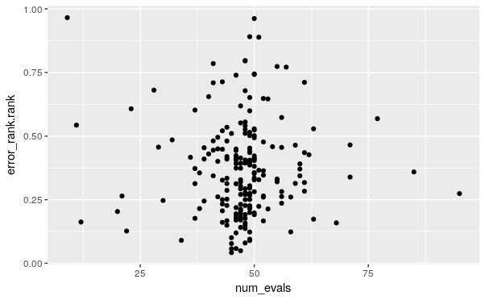

```r
V <- as.matrix(V_df[, -c(1,2)])
error_rank_u <- function(usuario){
  factores_u <- muestra_usuarios %>%
    filter(id == usuario) %>% pull(features) %>% unlist
  prefs_pred <- V %*% factores_u
  prefs_df <- data_frame(prefs_pred = as.numeric(prefs_pred),
             user_num = usuario,
             artist_num = V_df$id,
             preds_rank = 1 - rank(prefs_pred)/length(prefs_pred))
  obs_df <- lastfm_tbl %>% filter(user_num == usuario) %>% collect()
  prefs_df <- obs_df %>% left_join(prefs_df, by = c('user_num', 'artist_num'))
  error_rank <- prefs_df %>% ungroup %>%
    summarise(rank = sum(as.numeric(preds_rank*plays))/sum(as.numeric(plays)))
  c(error_rank = error_rank, num_evals = nrow(prefs_df))
}
errores_rank_entrena <-
  muestra_usuarios$id[100:300] %>%
  map(error_rank_u) %>%
  transpose %>% map(unlist) %>%
  as_data_frame
ggplot(errores_rank_entrena, aes(x = num_evals, y = error_rank.rank)) +
  geom_point()
```

```r
mean(errores_rank_entrena$error_rank.rank)
```

```
[1] 0.3691366
```

### Ejercicio:

- Escoge los factores de las personas de manera aleatoria. ¿Cómo cambia la distribución de *rank*?
- Separa un conjunto de validación: selecciona un conjunto de usuarios, y quita al azar la mitad de sus evaluaciones.
- Haz pruebas cambiando la regularización, el número de factores y el número de iteraciones. ¿Qué tan bajo puedes hacer el valor de *rank* para entrenamiento y validación?